# Grays Harbor Recreational Crab Harvest Estimate

Pooled CPUE Model - 2024-25 Season Results Report

Washington Department of Fish and Wildlife

2026-07-11

> **How to read this report.** This is the results report for one seasonal harvest estimate from the pooled CPUE model. Code is hidden by default; use the **Code** buttons (or *Code > Show All Code* at the top right) to reveal any step. Each section states what it does, shows the notable tables and figures, and, for the diagnostic sections, notes what a healthy run should look like. The headline number is the port total in the Results section; always read it together with the convergence and PE-vs-BSS sections, which say how much to trust it.

## 1. Setup and configuration

Loads packages, sources the helper functions in `03_R_functions/`, applies the run configuration from `run_config.R`, and defines the two sub-seasons (ring-net-only and all-gear). Every user-selectable toggle for this run lives in `run_config.R`.

```r
###############################################################################
# Crab Creel Estimation - Westport / Grays Harbor  |  Pooled CPUE Model
# 2024-25 Season  |  Pipeline code v7.9 (2026-07-12)
#
# Estimates total recreational Dungeness crab harvest at Westport / Grays Harbor
# from a single pooled CPUE process shared across gear types. Three population
# components are estimated independently and summed to the port total:
#   1. Shore crabbers (dock + jetty + beach)   BSS + PE
#   2. Private boat crabbers                    BSS + PE
#   3. Commercial/charter boats                 census/tally
# Two gear-regime sub-seasons: ring-net only (Sep 16 - Nov 30, no pots) and
# all-gear (Dec 1 - Sep 15, pots allowed).
#
# CURRENT STATE (v7.9): both fitted components run on the gear-DEPLOYMENT effort
# unit (h = number_of_gear, L = tau), via the shared 03_R_functions/bss_effort_spec.R.
# Helper functions live in 03_R_functions/ (sourced wholesale in the setup chunk),
# and every user-selectable toggle lives in run_config.R (the single file you edit);
# this .Rmd's params block holds only model-internal tuning (sampler settings, gate
# and AR-selector thresholds).
#
# KEY FEATURES: adaptive AR(1) temporal resolution; B1_C weekend CPUE effect;
# L_effective day length estimated with uncertainty from I/E; data-driven R_G prior;
# gear-deployment effort scale (R_G_boat / tau_boat, tau_shore); scale-aware
# convergence gate; expected + predictive catch in the generated quantities.
#
# FULL CHANGE LOG (every version, newest first, with working notes):
#   07_documentation/BSS-GH-pooled-CPUE-model-development-history.md
# METHOD REFERENCE (the published method of record):
#   07_documentation/BSS-GH-pooled-CPUE-model-documentation.md
###############################################################################

# ===========================================================================
# 0. SETUP
# ===========================================================================

load.lib <- c("tidyverse","lubridate","suncalc","gt","patchwork","rstan","here","readxl")
install.lib <- load.lib[!load.lib %in% installed.packages()]
for(lib in install.lib) install.packages(lib, dependencies=TRUE)
sapply(load.lib, require, character=TRUE)
rstan_options(auto_write = TRUE)
purrr::walk(list.files(here("03_R_functions"), full.names = TRUE), source)

run_date <- format(Sys.Date(), "%Y%m%d")
output_dir <- here("05_output", run_date, "pooled-CPUE")
if (!dir.exists(output_dir)) dir.create(output_dir, recursive = TRUE)

# timer_start() / timer_stop() and their timing state now live in
# 03_R_functions/bss_timers.R (auto-sourced). Read collected timings with
# bss_timer_log(). Extracted; behavior unchanged.

run_start_time <- Sys.time()

# ===========================================================================
# 0.1 PARAMETERS
# ===========================================================================

params <- list(
  # NOTE: every user-selectable toggle (season window, structural dates, catch
  # groups, day-typing, effort unit, incomplete-trip filter, I/E settings,
  # holidays, and the model-behavior levers such as collapse_mu_hier) now lives in
  # run_config.R, the single source of truth, and is applied as an override below.
  # This list holds ONLY this model's internal tuning: the Stan model file, the
  # per-fit sampler settings, the convergence-gate thresholds, and the adaptive
  # AR-selector thresholds. These rarely change and legitimately differ from the
  # gear-resolved model, so they stay with the model rather than in run_config.

  # --- Stan model file ---
  bss_model_file    = "crab_bss_pooled.stan",

  # --- BSS sampler defaults ---
  bss_adapt_delta   = 0.9,

  # --- BSS convergence tuning (extra iterations for longer sub-seasons / daily AR) ---
  bss_iter_default          = 3000,
  bss_warmup_default        = 1500,
  bss_max_treedepth_default = 10,
  bss_iter_shore_allgear    = 5000,
  bss_warmup_shore_allgear  = 2500,

  # Per-fit treedepth / adapt_delta overrides (v6.1, ported from gear-resolved
  # v5.2). The shore all-gear daily-AR posterior is the densest geometry and
  # saturated max_treedepth=10 on 91.6% of iterations in the 2026-04-08 run;
  # ring-net fits are data-sparse and benefit from tighter adaptation. Any fit
  # without an override uses the *_default values.
  bss_treedepth_shore_allgear = 14,
  bss_delta_shore_allgear     = 0.95,
  bss_treedepth_ringnet       = 12,
  bss_delta_ringnet           = 0.95,

  # v6.2: boat all-gear sampler tuning. The boat all-gear fit failed in the
  # 2026-04-08 run (5998 divergences, R-hat 1.074, n_eff 76) under defaults.
  # treedepth_pct was 0, so divergences came from step size: adapt_delta is
  # raised to 0.99 (primary lever) and max_treedepth to 13 (buffer), with more
  # iterations to give n_eff a chance to clear 400.
  bss_iter_boat_allgear       = 5000,
  bss_warmup_boat_allgear     = 2500,
  bss_treedepth_boat_allgear  = 13,
  bss_delta_boat_allgear      = 0.99,

  bss_min_interviews = 20,

  # --- B1.8: SCALE-AWARE convergence gate thresholds --------------------------
  # The gate rejects a BSS fit whose divergent transitions have BIASED the
  # reported totals, while accepting a fit whose divergences are diffuse and
  # harmless (Betancourt 2017). It measures the divergent draws' impact on each
  # reported TOTAL in units of that total's posterior SD (scale-invariant):
  #   impact = |median(all_draws) - median(bulk_draws)| / sd(all_draws)
  # A fit passes when max(impact_C, impact_E) is below max_divergence_total_impact_sd,
  # with a hard divergent-FRACTION backstop (max_divergence_fraction). See the
  # model documentation and development history for the full B1.8 rationale.
  max_divergence_total_impact_sd = 0.10,
  # P7 (2026-07-12): tightened from 0.15 to 0.05. The scale-aware impact test above
  # (max_divergence_total_impact_sd) is the primary gate; this fraction is only a hard
  # backstop, and 0.15 was too loose to defend for a publication method (a fit at ~14%
  # divergences would have passed as BSS). 0.05 matches the gear-resolved model. The
  # 2026-07-11 pooled fits (0.54%, 2.23%, 2.5% divergences) are all under 5%, so this
  # changes no current gating decision; divergences indicate biased HMC exploration
  # (Betancourt 2017), so the backstop belongs near 5%.
  max_divergence_fraction        = 0.05,
```

```r
  # --- DEPRECATED gate parameters (retained for reference; no longer gating) ---
  # Superseded by the scale-aware gate above. The level-normalized distortion is
  # still COMPUTED and reported in convergence_report.csv (distortion_C /
  # distortion_E) for continuity, but neither value participates in pass/fail.
  max_divergences = 5,
  max_divergence_distortion = 0.02,

  # --- Adaptive AR temporal-resolution thresholds -----------------------------
  # The model selects the finest AR resolution the data can support:
  #   daily:   effort obs on >= ar_daily_min_coverage of days AND >= ar_daily_min_obs
  #   weekly:  >= ar_weekly_min_per_week effort obs per week on average
  #   monthly: fallback for sparse data
  ar_daily_min_coverage  = 0.25,
  ar_daily_min_obs       = 20,
  ar_weekly_min_per_week = 1.5,

  # v6.5 (B1): per-population cap on AR resolution. The map now lives in run_config.R
  # (ar_max_resolution$pooled) so both models' caps sit in one place; this model's cap
  # is selected from it just after the merge below (P5, 2026-07-12). The boat
  # (trailer-count) effort series is too weakly informative for daily AR, so the boat
  # is capped at weekly; a population absent from the map defaults to "daily" (no cap).

  # --- I/E diagnostics ---
  ie_use_all_dates_for_diagnostics = TRUE
)

# --- Run-level config from run_config.R (single source of truth) --------------
# run_config.R owns every user-selectable toggle (season window, structural dates,
# catch groups, day-typing, effort unit, filters, I/E settings, holidays, the AR
# resolution map, and the model-behavior toggles). When launched via run_estimation.R
# the orchestrator has already defined `run_config`; when this .Rmd is knit standalone
# the guard below sources run_config.R so the same toggles are used either way.
if (!exists("run_config")) source(here::here("run_config.R"))
# P5 (2026-07-12): run_config is the BASE parameter set; this model's internal tuning
# (defined above) is layered on top. The two key sets are disjoint, so the merge order
# carries intent only (run_config is the base, the model updates it with its specifics).
params <- modifyList(run_config, params)
# Select this model's AR-resolution cap from the shared per-model map in run_config.
params$ar_max_resolution <- run_config$ar_max_resolution$pooled

# Crabbing holidays come from run_config (single source of truth). Kept as a bare
# object so any inline reference in this driver still resolves.
crabbing_holiday_dates <- params$crabbing_holiday_dates


catch_groups <- if(params$estimate_red_rock) {
  c("Dungeness_Kept", "Red_Rock_Kept")
} else {
  "Dungeness_Kept"
}

subseason_1 <- list(
  name = "ring_net_only",
  start = as.Date(params$est_date_start),
  end   = as.Date(params$pot_open_date) - 1
)
subseason_2 <- list(
  name = "all_gear",
  start = as.Date(params$pot_open_date),
  end   = as.Date(params$est_date_end)
)

cat(sprintf("Sub-season 1 (ring-net): %s to %s (%d days)\n",
            subseason_1$start, subseason_1$end,
            as.integer(subseason_1$end - subseason_1$start + 1)))
cat(sprintf("Sub-season 2 (all-gear): %s to %s (%d days)\n",
            subseason_2$start, subseason_2$end,
            as.integer(subseason_2$end - subseason_2$start + 1)))
cat(sprintf("Catch groups: %s\n", paste(catch_groups, collapse = ", ")))


# ===========================================================================
# 0.2 STANDALONE DAY-TYPE CLASSIFIER
#
# Assigns day_type to ANY date, independent of the estimation calendar.
# Use this for diagnostic plots that may show data outside the estimation
# period (e.g., effort data collected year-round but est_date_end is Jan 31).
# ===========================================================================

# classify_day_type() now lives in 03_R_functions/classify_day_type.R
# (auto-sourced). Signature is now (dates, params); it reads weekends/holidays
# from params. Behavior unchanged.


# ===========================================================================
# 1. DATA INGESTION
# ===========================================================================

# fetch_crab_data() now lives in 03_R_functions/fetch_crab_data.R
# (auto-sourced). Extracted verbatim; behavior unchanged.


# ===========================================================================
# 1.5 INGRESS/EGRESS DATA
# ===========================================================================

# fetch_ie_data() now lives in 03_R_functions/bss_day_length.R, shared with the
# gear-resolved driver so the two cannot drift. It is auto-sourced by the
# purrr::walk over 03_R_functions/ near the top of this file. Function body
# moved verbatim; behavior unchanged.


# ===========================================================================
# 1.6 L_EFFECTIVE MODEL - Regression with uncertainty propagation
#
# Fits a
# regression of log(L_effective) on day-of-year (quadratic) and day type.
# This captures the seasonal gradient WITHIN sub-seasons and provides
# per-day prediction uncertainty for propagation into the Stan model.
#
# Returns: list with
#   $predict_fn: function(event_date, day_type) -> tibble(L_mu, L_sigma)
#   $model: the fitted lm object
#   $detail: per-I/E-day data
#   $summary: model coefficients and fit statistics
# ===========================================================================

# estimate_L_effective() now lives in 03_R_functions/bss_day_length.R, shared
# with the gear-resolved driver so the two cannot drift. It is auto-sourced by
# the purrr::walk over 03_R_functions/ near the top of this file. Function body
# moved verbatim; behavior unchanged.


# ===========================================================================
# 2. PREP DAYS - Build calendar with L_mu and L_sigma per day
#
# Stores both L_mu (predicted median) and L_prior_sigma
# lookup value, store both L_mu (predicted median) and L_prior_sigma
# (prediction uncertainty on log scale) for each day. These feed into
# the Stan model where L becomes a parameter.
# ===========================================================================
```

```r
# prep_days_crab() now lives in 03_R_functions/prep_days_crab.R (shared,
# auto-sourced). Signature is now (date_begin, date_end, params, L_eff_model);
# it derives weekends/holidays/period_pe/sections from params. Behavior unchanged.


# ===========================================================================
# 3. SUMMARIZE DATA - Filter to population x sub-season
# ===========================================================================

# prep_population_summary() now lives in
# 03_R_functions/prep_population_summary.R (shared, auto-sourced). catch_groups is
# derived from params inside. Behavior unchanged.


# ===========================================================================
# 4. PE METHOD - (unchanged from v1)
# ===========================================================================

# run_pe_pooled() now lives in 03_R_functions/run_pe_pooled.R (auto-sourced).
# catch_groups is derived from params; the shore branch now flows through
# bss_effort_spec() so shore PE matches the shore BSS unit (2026-07-11 fix).


# ===========================================================================
# 5. BSS PREP - Build Stan data list for crab_bss_pooled.stan
#
# ADAPTIVE AR RESOLUTION: Selects daily, weekly, or monthly AR based on
# effort data density. Dense data → daily AR for smooth interpolation.
# Sparse data → coarser resolution to avoid poorly-identified AR dynamics.
#
# Also includes: data-driven R_G prior, L_effective as parameter (shore),
# informative R_G_boat prior, tightened Cauchy scales, no interview cap.
# ===========================================================================

# prep_bss_crab_pooled() now lives in 03_R_functions/prep_bss_crab_pooled.R
# (auto-sourced). Extracted verbatim (renamed); behavior unchanged.


# ===========================================================================
# 6. COMMERCIAL/CHARTER CENSUS (unchanged from v1)
# ===========================================================================

# estimate_comm_charter() now lives in 03_R_functions/estimate_comm_charter.R
# (shared, auto-sourced). crabbing_holiday_dates read from params. Behavior unchanged.


# ===========================================================================
# 7. RUN EVERYTHING
# ===========================================================================
```

## 2. Data ingestion

Reads the season’s effort counts, crabber interviews, commercial tally, and ingress/egress (I/E) surveys, and classifies each interview into shore, private-boat, or commercial/charter.

```r
# ---- 7.0 LOAD DATA ----
timer_start("1_load_data")
cat("\n", strrep("=",60), "\n LOADING DATA\n", strrep("=",60), "\n")
dwg <- fetch_crab_data(params)
ie_data <- fetch_ie_data(params)

# --- Fit L_effective regression ---
L_eff_model <- NULL
if(isTRUE(params$use_ie_day_length) && nrow(ie_data) > 0) {
  L_eff_model <- estimate_L_effective(ie_data, params$pot_open_date, params)
  if(!is.null(L_eff_model)) {
    # Save regression diagnostics
    if(!is.null(L_eff_model$detail)) {
      write.csv(L_eff_model$detail,
                file.path(output_dir, "L_effective_ie_detail.csv"), row.names = FALSE)
    }
  }
}
timer_stop("1_load_data")
```

## 3. Input diagnostics: effort, CPUE, and day length

Diagnostic views of the raw inputs before any modeling: sampled effort over the season by day type, interview CPUE over time, and the effective day length derived from the I/E surveys. Use these to spot data gaps or anomalies (for example a run of unsampled weekends, or an implausible CPUE spike).

```r
# ---- 7.1 DIAGNOSTIC PLOTS ----
timer_start("2_diagnostic_plots")
cat("\n", strrep("=",60), "\n DIAGNOSTIC PLOTS\n", strrep("=",60), "\n")

days_full <- prep_days_crab(params$est_date_start, params$est_date_end,
                            params, L_eff_model = L_eff_model)

# Plot 1: Shore gear count timeseries
p_shore_effort <- dwg$shore_effort |>
  group_by(event_date) |>
  summarise(total_gear = sum(count_quantity), n_counts = n(), .groups = "drop") |>
  mutate(day_type = classify_day_type(event_date, params)) |>
  ggplot(aes(x = event_date, y = total_gear, color = day_type, size = n_counts)) +
  geom_point(alpha = 0.5) +
  geom_vline(xintercept = as.Date(params$pot_open_date), linetype = "dashed", color = "red", linewidth = 0.5) +
  annotate("text", x = as.Date(params$pot_open_date) + 5, y = Inf, label = "Pots open",
           hjust = 0, vjust = 1.5, size = 3, color = "red") +
  scale_size_continuous(range = c(1,3), breaks = 1:3, name = "Counts/day") +
  labs(title = "Shore: Daily Gear Count (Docks F20 + F17-21)",
       x = "Date", y = "Total gear count", color = "Day type") +
  theme_bw()
ggsave(file.path(output_dir, "plot_shore_effort_timeseries.png"), p_shore_effort, width = 10, height = 6)

# Plot 2: Boat trailer count timeseries
p_boat_effort <- dwg$boat_effort |>
  group_by(event_date) |>
  summarise(total_trailers = sum(count_quantity), n_counts = n(), .groups = "drop") |>
  mutate(day_type = classify_day_type(event_date, params)) |>
  ggplot(aes(x = event_date, y = total_trailers, color = day_type)) +
  geom_point(alpha = 0.5) +
  geom_vline(xintercept = as.Date(params$pot_open_date), linetype = "dashed", color = "red", linewidth = 0.5) +
  labs(title = "Private Boat: Daily Trailer Count", x = "Date", y = "Trailers", color = "Day type") +
  theme_bw()
ggsave(file.path(output_dir, "plot_boat_effort_timeseries.png"), p_boat_effort, width = 10, height = 6)

# Plot 3: CPUE by population
cpue_data <- dwg$interview |>
  filter(fishing_time_total > 0, dungeness_kept >= 0) |>
  mutate(cpue = dungeness_kept / fishing_time_total) |>
  group_by(event_date, population) |>
  summarise(mean_cpue = mean(cpue), n_int = n(), .groups = "drop") |>
  mutate(day_type = classify_day_type(event_date, params)) |>
  filter(population %in% c("shore", "private_boat"))

p_cpue <- cpue_data |>
  ggplot(aes(x = event_date, y = mean_cpue, color = day_type)) +
  geom_point(alpha = 0.4, size = 1.5) +
  geom_smooth(method = "loess", span = 0.3, se = TRUE, color = "grey30") +
  geom_vline(xintercept = as.Date(params$pot_open_date), linetype = "dashed", color = "red") +
  facet_wrap(~population, ncol = 1, scales = "free_y") +
  labs(title = "Dungeness CPUE by Population", x = "Date", y = "Mean CPUE", color = "Day type") +
  theme_bw()
ggsave(file.path(output_dir, "plot_cpue_timeseries.png"), p_cpue, width = 10, height = 8)

# Plot 4: Gear counts by month and day type (boxplot)
p_effort_month <- dwg$shore_effort |>
  group_by(event_date) |>
  summarise(total_gear = sum(count_quantity), .groups = "drop") |>
  mutate(day_type = classify_day_type(event_date, params),
         month_label = factor(format(event_date, "%Y-%m"))) |>
  ggplot(aes(x = month_label, y = total_gear, fill = day_type)) +
  geom_boxplot() +
  labs(title = "Shore Gear Counts by Month and Day Type",
       x = "Month", y = "Daily gear count", fill = "Day type") +
  theme_bw() +
  theme(axis.text.x = element_text(angle = 45, hjust = 1))
ggsave(file.path(output_dir, "plot_effort_by_month.png"), p_effort_month, width = 12, height = 6)

# L_effective regression diagnostic plot
if(!is.null(L_eff_model) && !is.null(L_eff_model$detail) && nrow(L_eff_model$detail) >= 3) {
  # Predict L for a full year of days for visualization
  viz_dates <- seq.Date(as.Date("2024-01-01"), as.Date("2024-12-31"), by = "day")
  viz_pred <- L_eff_model$predict_fn(viz_dates, rep("weekday", length(viz_dates)))
  viz_pred_wkend <- L_eff_model$predict_fn(viz_dates, rep("weekend", length(viz_dates)))

  p_L_regression <- ggplot() +
    geom_ribbon(data = tibble(date = viz_dates, lo = viz_pred$L_mu * exp(-1.96 * viz_pred$L_sigma),
                              hi = viz_pred$L_mu * exp(1.96 * viz_pred$L_sigma)),
                aes(x = date, ymin = lo, ymax = hi), alpha = 0.15, fill = "steelblue") +
    geom_line(data = tibble(date = viz_dates, L = viz_pred$L_mu),
              aes(x = date, y = L, color = "Weekday prediction"), linewidth = 0.8) +
    geom_line(data = tibble(date = viz_dates, L = viz_pred_wkend$L_mu),
              aes(x = date, y = L, color = "Weekend prediction"), linewidth = 0.8, linetype = "dashed") +
    geom_point(data = L_eff_model$detail,
               aes(x = event_date, y = L_effective, shape = day_type_group), size = 3) +
    labs(title = "L_effective Regression (log-scale quadratic + day type)",
         subtitle = sprintf("Method: %s | n=%d I/E days | Shaded = 95%% prediction interval",
                            L_eff_model$method, L_eff_model$n_obs),
         x = "Date", y = "L_effective (hours)", color = "Prediction", shape = "I/E day type") +
    theme_bw()
  ggsave(file.path(output_dir, "plot_L_effective_regression.png"), p_L_regression, width = 12, height = 6)
}

# Day length comparison (civil twilight vs regression)
p_day_length <- days_full |>
  ggplot(aes(x = event_date)) +
  geom_line(aes(y = day_length_civil_twilight, color = "Civil twilight"), alpha = 0.5) +
  geom_ribbon(aes(ymin = L_mu * exp(-1.96 * L_prior_sigma),
                  ymax = L_mu * exp(1.96 * L_prior_sigma)),
              alpha = 0.15, fill = "steelblue") +
  geom_line(aes(y = L_mu, color = "I/E L_effective (regression)"), linewidth = 0.8) +
  labs(title = "Day Length with Uncertainty",
       subtitle = "Shaded band = 95% prior interval for L (propagated into Stan model)",
       x = "Date", y = "Day length (hours)", color = "Method") +
  scale_color_manual(values = c("Civil twilight" = "grey60", "I/E L_effective (regression)" = "steelblue")) +
  theme_bw()
ggsave(file.path(output_dir, "plot_day_length_comparison.png"), p_day_length, width = 10, height = 5)

cat("  Diagnostic plots saved.\n")
timer_stop("2_diagnostic_plots")
```

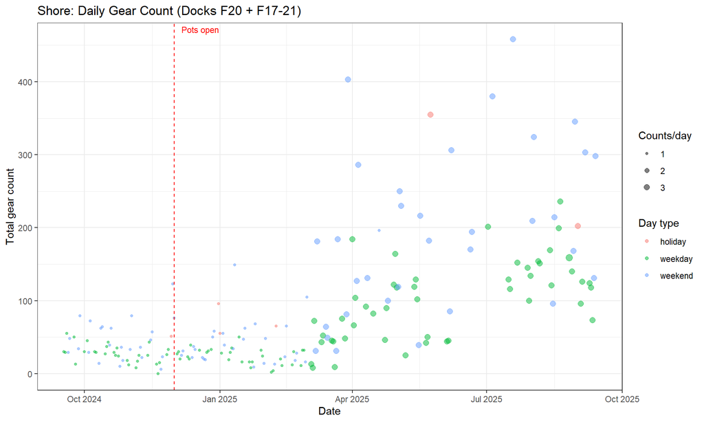

Shore effort (gear counts) over the season by day type.

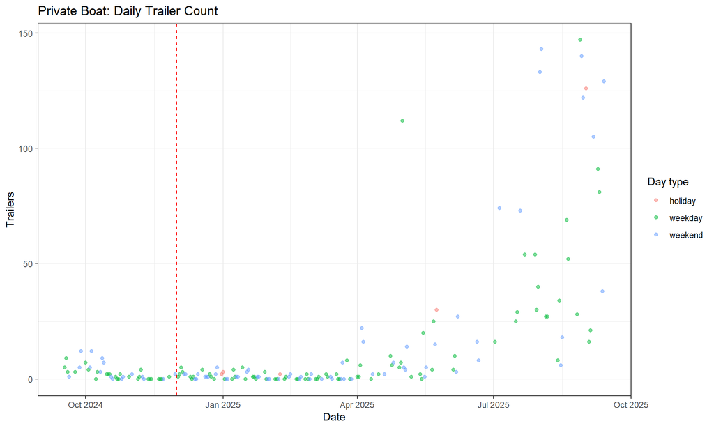

Private-boat effort (trailer counts) over the season by day type.

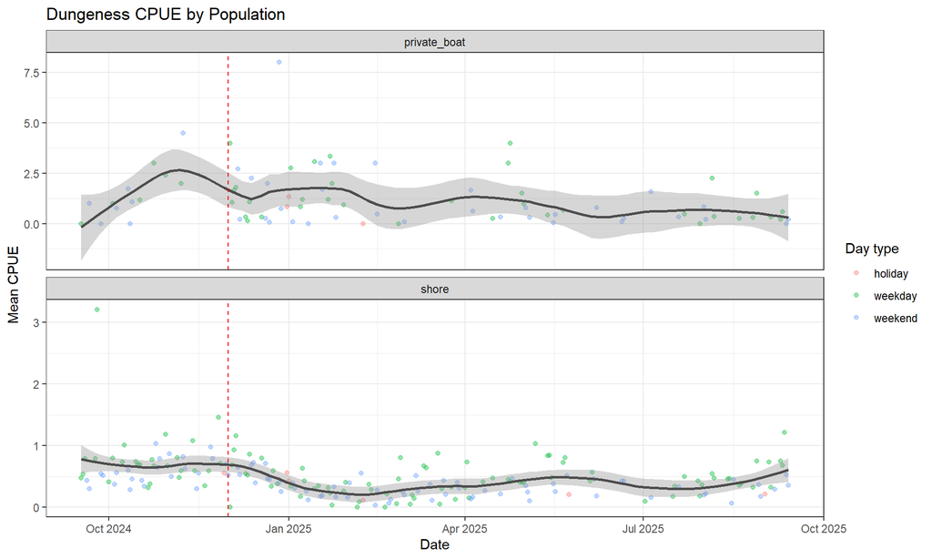

Interview CPUE over the season.

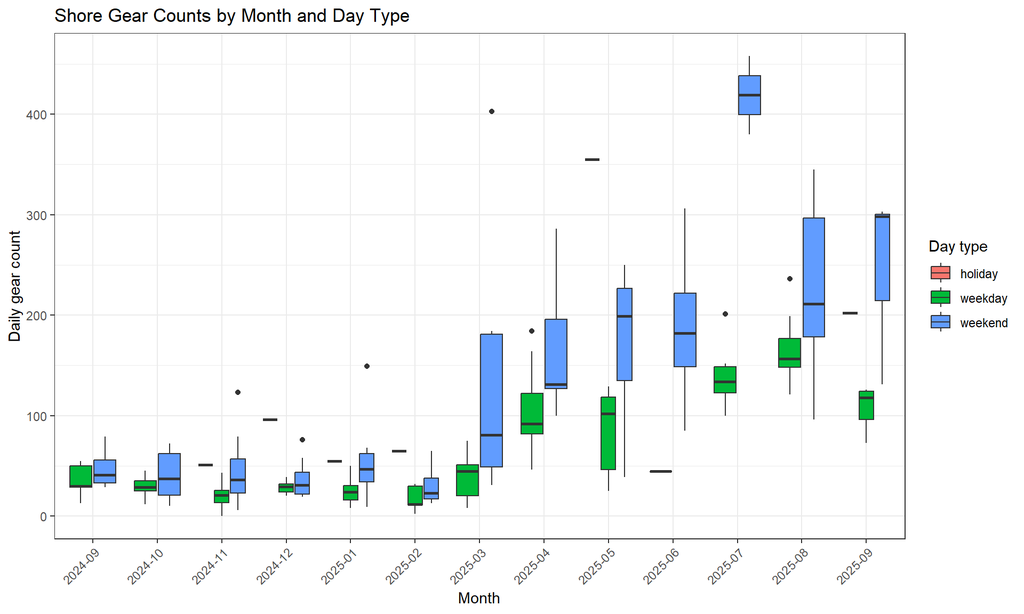

Effort by month.

```r
for (nm in c('p_shore_effort','p_boat_effort','p_cpue','p_effort_month')) if (exists(nm)) print(get(nm))
```

### 3.1 Ingress/egress and effective day length

The I/E surveys measure how long crabbers are actually present, which sets the effective day length used to expand snapshot effort counts. Civil twilight (9 to 17 hours) would overstate active fishing time by roughly a factor of two, so the I/E-derived length is used instead.

```r
# ---- 7.1b I/E ANALYSIS ----
cat("\n", strrep("=",60), "\n I/E ANALYSIS\n", strrep("=",60), "\n")

if(nrow(ie_data) > 0) {
  ie_validation <- ie_data |>
    filter(population == "shore") |>
    left_join(
      dwg$shore_effort |>
        group_by(event_date) |>
        summarise(mean_gear = mean(count_quantity), n_counts = n(), .groups = "drop"),
      by = "event_date"
    ) |>
    filter(!is.na(mean_gear), mean_gear > 0)

  if(nrow(ie_validation) > 0) {
    # Shared helper (03_R_functions/bss_day_length.R) so the [9, 17] cap lives in
    # exactly one place; this previously hardcoded a 16.0 cap.
    ie_validation$day_length_ct <- bss_day_length_civil(ie_validation$event_date, params)

    summ_shore_full <- prep_population_summary(dwg, "shore", params$est_date_start, params$est_date_end, params)
    cpg <- summ_shore_full$crabbers_per_gear

    ie_validation <- ie_validation |>
      mutate(
        gear_est_crabber_hrs = mean_gear * cpg * day_length_ct,
        f_temporal = ie_crabber_hours / gear_est_crabber_hrs,
        pct_error = (gear_est_crabber_hrs - ie_crabber_hours) / ie_crabber_hours * 100
      )

    cat("\n  I/E vs Gear-Count Comparison (paired days):\n")
    for(i in 1:nrow(ie_validation)) {
      r <- ie_validation[i,]
      cat(sprintf("  %-12s %-8s IE=%.0f Gear_est=%.0f f=%.2f\n",
                  as.character(r$event_date), r$day_type, r$ie_crabber_hours,
                  r$gear_est_crabber_hrs, r$f_temporal))
    }
    write.csv(ie_validation |>
      select(event_date, day_type, ie_crabber_hours, max_present, mean_present,
             L_effective, mean_gear, n_counts, gear_est_crabber_hrs, f_temporal, pct_error),
      file.path(output_dir, "ie_analysis.csv"), row.names = FALSE)
  }
} else {
  cat("  No I/E data available.\n")
}
```

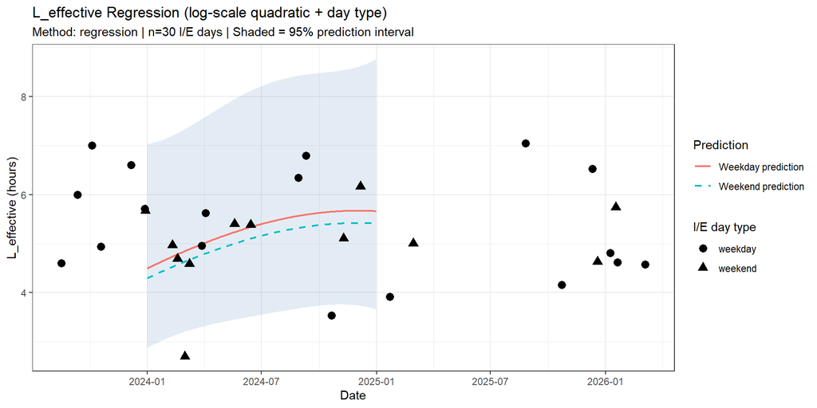

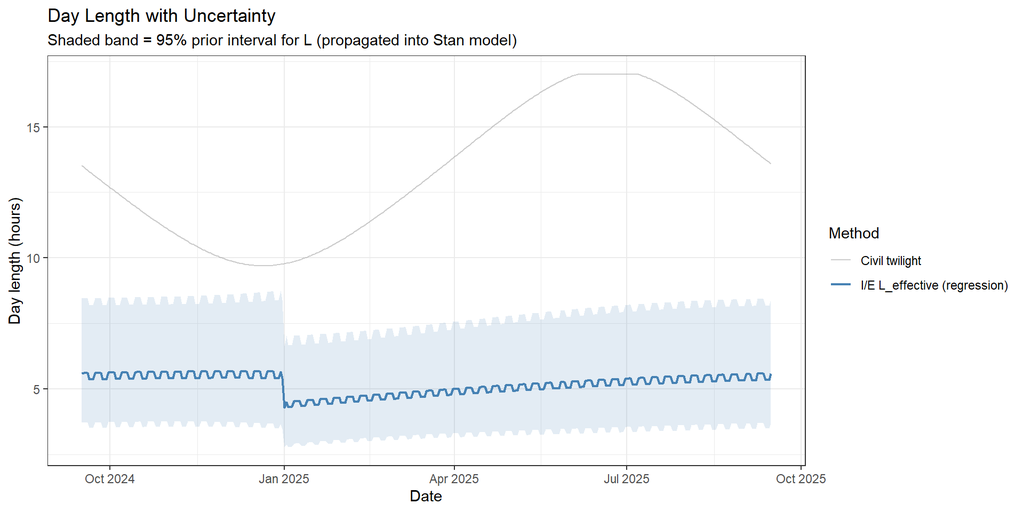

```r
for (nm in c('p_L_regression','p_day_length')) if (exists(nm)) print(get(nm))
```

## 4. Point Estimator (PE)

The design-based estimator: it averages sampled days within each stat-week by day-type stratum and expands to the unsampled days. The PE is fast and transparent, and it is the fallback whenever a Bayesian fit does not pass the convergence gate.

```r
# ---- 7.2 PE ESTIMATES ----
timer_start("3_PE_estimates")
cat("\n", strrep("=",60), "\n PE ESTIMATES\n", strrep("=",60), "\n")

pe_all <- list()
for(pop in c("shore","private_boat")) {
  for(ss in list(subseason_1, subseason_2)) {
    label <- paste0(pop, "_", ss$name)
    days_ss <- prep_days_crab(ss$start, ss$end, params, L_eff_model = L_eff_model)
    summ_ss <- prep_population_summary(dwg, pop, ss$start, ss$end, params)
    pe_all[[label]] <- run_pe_pooled(summ_ss, days_ss, params, label)
  }
}
timer_stop("3_PE_estimates")
```

### 4.1 Incomplete-trip sensitivity

Incomplete trips (gear not yet retrieved at the interview) read systematically low for pots and traps. This section quantifies the harvest difference between keeping and dropping them; the production default drops them (`filter_incomplete_trips = TRUE`).

```r
# ---- 7.2b POOL-2: INCOMPLETE-TRIP SENSITIVITY ----
# Quantify the harvest impact of the incomplete-trip filter: re-run the fast,
# design-based PE estimator with the filter OFF vs ON for each shore/boat
# sub-season and report the % change in Dungeness catch. Incomplete trips read
# ~-20% low for soak-time gear, so the filtered (complete-only) estimate is
# expected to be higher. This section is DIAGNOSTIC ONLY: it re-runs PE (no MCMC),
# changes no reported total, and is tryCatch-wrapped so it can never break the
# run. Output: sensitivity_incomplete_trips.csv.
cat("\n", strrep("=",60), "\n INCOMPLETE-TRIP SENSITIVITY (POOL-2)\n", strrep("=",60), "\n")
tryCatch({
  sens_rows <- list()
  for(pop in c("shore","private_boat")) {
    for(ss in list(subseason_1, subseason_2)) {
      s_label <- paste0(pop, "_", ss$name)
      days_ss <- prep_days_crab(ss$start, ss$end, params, L_eff_model = L_eff_model)
      summ_ss <- prep_population_summary(dwg, pop, ss$start, ss$end, params)
      p_off   <- modifyList(params, list(filter_incomplete_trips = FALSE))
      p_on    <- modifyList(params, list(filter_incomplete_trips = TRUE))
      d_off   <- run_pe_pooled(summ_ss, days_ss, p_off, paste0(s_label, " [all trips]"))$Dungeness_Kept %||% 0
      d_on    <- run_pe_pooled(summ_ss, days_ss, p_on,  paste0(s_label, " [complete only]"))$Dungeness_Kept %||% 0
      sens_rows[[s_label]] <- tibble(
        component                  = s_label,
        PE_Dungeness_all_trips     = round(d_off),
        PE_Dungeness_complete_only = round(d_on),
        diff_pct                   = if(d_off > 0) round((d_on - d_off) / d_off * 100, 1) else NA_real_
      )
    }
  }
  sens_df <- bind_rows(sens_rows)
  sens_df$filter_applied_in_run <- isTRUE(params$filter_incomplete_trips)
  print(sens_df)
  write.csv(sens_df, file.path(output_dir, "sensitivity_incomplete_trips.csv"), row.names = FALSE)
}, error = function(e) cat(sprintf("  Incomplete-trip sensitivity skipped: %s\n", conditionMessage(e))))
```

[output not shown]

### 4.2 Commercial and charter census

The commercial and charter harvest is a day-type-stratified census expansion of the daily vessel tally, not a modeled quantity.

```r
# ---- 7.4 COMMERCIAL/CHARTER ----
timer_start("4_commercial_charter")
pe_all$comm_charter <- estimate_comm_charter(dwg, params)
timer_stop("4_commercial_charter")
```

### 4.3 PE port totals

The Point Estimator port total, summed across the three population components. Compare it against the Bayesian total below.

```r
# ---- 7.5 PE PORT TOTALS ----
cat("\n", strrep("=",60), "\n PE PORT TOTALS\n", strrep("=",60), "\n")

component_names <- c("Shore (ring-net)","Shore (all-gear)","Private Boat (ring-net)",
                     "Private Boat (all-gear)","Commercial/Charter","PORT TOTAL")
component_keys <- c("shore_ring_net_only","shore_all_gear",
                    "private_boat_ring_net_only","private_boat_all_gear","comm_charter")

pe_summary <- tibble(
  Component = component_names,
  Effort_hrs = c(sapply(component_keys, function(k) pe_all[[k]]$effort_total), NA),
  Dungeness = c(sapply(component_keys, function(k) pe_all[[k]]$Dungeness_Kept), NA)
)
pe_summary$Effort_hrs[6] <- sum(pe_summary$Effort_hrs[1:5], na.rm=TRUE)
pe_summary$Dungeness[6] <- sum(pe_summary$Dungeness[1:5], na.rm=TRUE)

if(params$estimate_red_rock) {
  pe_summary$Red_Rock <- c(
    sapply(component_keys, function(k) pe_all[[k]]$Red_Rock_Kept %||% 0), NA)
  pe_summary$Red_Rock[6] <- sum(pe_summary$Red_Rock[1:5], na.rm=TRUE)
}

print(pe_summary |> mutate(across(where(is.numeric), ~round(.))))
write.csv(pe_summary, file.path(output_dir, "pe_port_summary.csv"), row.names=FALSE)
```

```r
report_table(pe_summary, 'Point Estimator (PE) port totals by component.')
```

Point Estimator (PE) port totals by component.

| Component | Effort_hrs | Dungeness |
| --- | --- | --- |
| Shore (ring-net) | 4,485.73 | 5,884.18 |
| Shore (all-gear) | 18,104.06 | 15,732.29 |
| Private Boat (ring-net) | 583.91 | 971.29 |
| Private Boat (all-gear) | 11,885.84 | 22,070.26 |
| Commercial/Charter | 282.81 | 12,007.12 |
| PORT TOTAL | 35,342.35 | 56,665.15 |

## 5. Bayesian state-space model fits

Each population by sub-season is fit independently with a Bayesian state-space (BSS) model that treats daily effort and catch rate as smoothly evolving latent series, fills the gaps between sampled days, and returns full credible intervals. **What a healthy fit looks like:** R-hat below 1.01, effective sample size above 400, and few or no divergent transitions on every monitored quantity. Fits are checked against these criteria in the next section.

```r
# ---- 7.6 BSS MODEL RUNS ----
timer_start("5_BSS_model_runs")
cat("\n", strrep("=",60), "\n BSS MODEL RUNS (Adaptive AR)\n", strrep("=",60), "\n")

bss_catch_groups <- catch_groups
bss_all <- list()
ar_resolutions <- list()  # track AR resolution per fit

for(cg in bss_catch_groups) {
  for(pop in c("shore","private_boat")) {
    for(ss in list(subseason_1, subseason_2)) {
      label <- paste0(pop, "_", ss$name, "_", cg)
      cat(sprintf("\n--- BSS: %s ---\n", label))

      days_ss <- prep_days_crab(ss$start, ss$end, params, L_eff_model = L_eff_model)
      summ_ss <- prep_population_summary(dwg, pop, ss$start, ss$end, params)

      # NOTE (POOL-2): n_int is the UNFILTERED interview count. The fitted CPUE
      # count is lower once prep_bss_crab drops h<=0 rows and (with
      # filter_incomplete_trips = TRUE) incomplete trips, so this sufficiency
      # guard reads looser than the count the fit actually uses. Behavior is
      # unchanged from prior versions (the guard was always pre-filter); on the
      # 2024-25 data every fitted component keeps well over bss_min_interviews
      # complete interviews. If a future component is marginal, gate on the
      # complete-only count instead.
      n_int <- nrow(summ_ss$interview)
      n_eff <- nrow(summ_ss$effort_index)

      if(n_eff < 5 || n_int < params$bss_min_interviews) {
        cat(sprintf("  Insufficient data (%d effort, %d interviews), PE fallback.\n", n_eff, n_int))
        bss_all[[label]] <- list(C_sum=NA, E_sum=NA, pe_fallback=TRUE,
                                 population=pop, subseason=ss$name, catch_group=cg)
        next
      }

      bss_data <- prep_bss_crab_pooled(days_ss, summ_ss, cg, params, pop, ie_data = ie_data)
      ar_resolutions[[label]] <- attr(bss_data, "ar_resolution")

      is_shore   <- (pop == "shore")
      is_boat    <- (pop == "private_boat")
      is_allgear <- (ss$name == "all_gear")
      is_ringnet <- (ss$name == "ring_net_only")

      # v6.1/v6.2: per-fit sampler tuning. Each branch sets iter, warmup,
      # max_treedepth, and adapt_delta; any fit without a specific override
      # uses the *_default values. Ported from the gear-resolved track (v6.1)
      # and extended with a boat all-gear branch (v6.2). The boat all-gear fit
      # produced 5998 divergences with treedepth_pct = 0 in the 2026-04-08 run,
      # so step size (adapt_delta), not trajectory length, was the binding
      # constraint: adapt_delta is raised to 0.99 and max_treedepth to 13 (the
      # smaller steps from a higher adapt_delta lengthen trajectories, so the
      # deeper tree is a buffer against new treedepth saturation).
      if(is_shore && is_allgear) {
        fit_iter    <- params$bss_iter_shore_allgear
        fit_warmup  <- params$bss_warmup_shore_allgear
        fit_treedep <- params$bss_treedepth_shore_allgear %||% params$bss_max_treedepth_default
        fit_delta   <- params$bss_delta_shore_allgear     %||% params$bss_adapt_delta
      } else if(is_boat && is_allgear) {
        fit_iter    <- params$bss_iter_boat_allgear      %||% params$bss_iter_default
        fit_warmup  <- params$bss_warmup_boat_allgear    %||% params$bss_warmup_default
        fit_treedep <- params$bss_treedepth_boat_allgear %||% params$bss_max_treedepth_default
        fit_delta   <- params$bss_delta_boat_allgear     %||% params$bss_adapt_delta
      } else if(is_ringnet) {
        fit_iter    <- params$bss_iter_default
        fit_warmup  <- params$bss_warmup_default
        fit_treedep <- params$bss_treedepth_ringnet %||% params$bss_max_treedepth_default
        fit_delta   <- params$bss_delta_ringnet     %||% params$bss_adapt_delta
      } else {
        fit_iter    <- params$bss_iter_default
        fit_warmup  <- params$bss_warmup_default
        fit_treedep <- params$bss_max_treedepth_default
        fit_delta   <- params$bss_adapt_delta
      }

      cat(sprintf("  Stan: iter=%d, warmup=%d, max_treedepth=%d, adapt_delta=%.2f, D=%d days, P_n=%d (%s), %d interviews\n",
                  fit_iter, fit_warmup, fit_treedep, fit_delta, bss_data$D, bss_data$P_n,
                  attr(bss_data, "ar_resolution"), bss_data$IntC))

      timer_start(paste0("BSS_", label))
      fit <- rstan::stan(
        file = here("02_stan_models", params$bss_model_file),
        data = bss_data,
        chains = params$bss_chains, iter = fit_iter, warmup = fit_warmup,
        control = list(adapt_delta=fit_delta, max_treedepth=fit_treedep),
        seed = params$bss_seed,
        cores = params$bss_cores
      )
      timer_stop(paste0("BSS_", label))

      # --- Extract BOTH expected and predictive catch ---
      bss_pars <- c("C_sum","C_expected_sum","E_sum","B1","B2","B1_C_out")
      if(bss_data$IE_n > 0) bss_pars <- c(bss_pars, "sigma_IE_out")
      bss_summ <- summary(fit, pars=bss_pars)$summary
      cat("  BSS Summary:\n"); print(bss_summ)
      write.csv(as.data.frame(bss_summ), file.path(output_dir, paste0("bss_summary_",label,".csv")))

      C_draws <- rstan::extract(fit, "C_sum")$C_sum           # predictive (with Poisson noise)
      C_exp_draws <- rstan::extract(fit, "C_expected_sum")$C_expected_sum  # expected (no noise)
      E_draws <- rstan::extract(fit, "E_sum")$E_sum

      bss_all[[label]] <- list(
        C_sum = quantile(C_draws, c(0.025,0.5,0.975)),
        C_expected_sum = quantile(C_exp_draws, c(0.025,0.5,0.975)),
        E_sum = quantile(E_draws, c(0.025,0.5,0.975)),
        C_draws = C_draws, C_exp_draws = C_exp_draws, E_draws = E_draws,
        fit = fit, pe_fallback = FALSE, bss_data = bss_data, days_ss = days_ss,
        population = pop, subseason = ss$name, catch_group = cg
      )

      # --- Use C_expected (no Poisson noise) for primary estimates ---
      E_bss <- rstan::extract(fit, "E")$E
      C_exp_bss <- rstan::extract(fit, "C_expected")$C_expected

      E_daily <- tibble(
        event_date = days_ss$event_date,
        median = apply(E_bss[,1,,1], 2, median),
        lo95 = apply(E_bss[,1,,1], 2, quantile, 0.025),
        hi95 = apply(E_bss[,1,,1], 2, quantile, 0.975)
      )

      C_daily <- tibble(
        event_date = days_ss$event_date,
        median = apply(C_exp_bss[,1,,1], 2, median),
        lo95 = apply(C_exp_bss[,1,,1], 2, quantile, 0.025),
        hi95 = apply(C_exp_bss[,1,,1], 2, quantile, 0.975)
      )

      # BSS effort plot
      p_bss_eff <- E_daily |>
        ggplot(aes(x = event_date)) +
        geom_ribbon(aes(ymin = lo95, ymax = hi95), alpha = 0.2, fill = "steelblue") +
        geom_line(aes(y = median), color = "steelblue") +
        labs(title = sprintf("BSS Daily Effort: %s", label),
             subtitle = "Median with 95% credible interval (daily AR(1))",
             x = "Date", y = "Crabber-hours") +
        theme_bw()
      ggsave(file.path(output_dir, paste0("plot_bss_effort_", label, ".png")),
             p_bss_eff, width = 10, height = 6)

      # BSS catch plot (using expected catch)
      p_bss_catch <- C_daily |>
        ggplot(aes(x = event_date)) +
        geom_ribbon(aes(ymin = lo95, ymax = hi95), alpha = 0.2, fill = "darkgreen") +
        geom_line(aes(y = median), color = "darkgreen") +
        labs(title = sprintf("BSS Daily Expected Catch: %s", label),
             subtitle = "E[C|data] with 95% CI (no Poisson sampling noise)",
             x = "Date", y = "Expected Dungeness caught") +
        theme_bw()
      ggsave(file.path(output_dir, paste0("plot_bss_catch_", label, ".png")),
             p_bss_catch, width = 10, height = 6)

      # Posterior densities
      p_bss_post <- tibble(
        `Expected Catch` = C_exp_draws,
        `Predictive Catch` = C_draws,
        `Effort` = E_draws
      ) |>
        pivot_longer(everything(), names_to = "param", values_to = "value") |>
        ggplot(aes(x = value, fill = param)) +
        geom_density(alpha = 0.4) +
        facet_wrap(~param, scales = "free") +
        labs(title = sprintf("BSS Posteriors: %s", label), x = "Value", y = "Density") +
        theme_bw() + theme(legend.position = "none")
      ggsave(file.path(output_dir, paste0("plot_bss_posteriors_", label, ".png")),
             p_bss_post, width = 14, height = 5)

      write.csv(E_daily, file.path(output_dir, paste0("bss_daily_effort_", label, ".csv")), row.names=FALSE)
      write.csv(C_daily, file.path(output_dir, paste0("bss_daily_catch_", label, ".csv")), row.names=FALSE)

      # Save L posterior if estimated
      if(bss_data$estimate_L == 1) {
        L_post <- rstan::extract(fit, "L_out")$L_out  # [draws, D]
        L_daily <- tibble(
          event_date = days_ss$event_date,
          L_prior_mu = days_ss$L_mu,
          L_posterior_median = apply(L_post, 2, median),
          L_posterior_lo95 = apply(L_post, 2, quantile, 0.025),
          L_posterior_hi95 = apply(L_post, 2, quantile, 0.975)
        )
        write.csv(L_daily, file.path(output_dir, paste0("bss_L_effective_", label, ".csv")), row.names=FALSE)
      }
    }
  }
}
timer_stop("5_BSS_model_runs")
```